# Machine Learning

Author

GROUP IV

# Machine Learning

1. Purpose

This section applies machine learning methods to analyze patterns in the 2024 job market dataset.  
We use one unsupervised learning model and two supervised learning models:

- **KMeans Clustering** to identify segments of job postings
- **Linear Regression** to examine the relationship between experience and salary
- **Logistic Regression** to classify whether a job is remote

The purpose of this section is to understand how experience, salary, and work format are connected, and to provide practical implications for job seekers.

2. Load Libraries and Data

We first import the necessary libraries and load the cleaned dataset.

```
(67572, 114)
```

|  | POSTED | EXPIRED | DURATION | SOURCE_TYPES | SOURCES | TITLE_RAW | BODY | MODELED_EXPIRED | MODELED_DURATION | COMPANY | ... | ORIGINAL_PAY_PERIOD | MIN_YEARS_EXPERIENCE | MAX_YEARS_EXPERIENCE | LIGHTCAST_SECTORS | LIGHTCAST_SECTORS_NAME | MIN_EDULEVELS | MIN_EDULEVELS_NAME | MAX_EDULEVELS | MAX_EDULEVELS_NAME | SALARY_MID |
| --- | --- | --- | --- | --- | --- | --- | --- | --- | --- | --- | --- | --- | --- | --- | --- | --- | --- | --- | --- | --- | --- |
| 0 | 6/2/2024 | 6/8/2024 | 6.0 | [\n "Company"\n] | [\n "brassring.com"\n] | Enterprise Analyst (II-III) | 31-May-2024\n\nEnterprise Analyst (II-III)\n\n... | 6/8/2024 | 6.0 | 894731.0 | ... | NaN | 2.0 | 2.0 | [\n 7\n] | [\n "Artificial Intelligence"\n] | 2.0 | Bachelor's degree | NaN | NaN | NaN |
| 1 | 6/2/2024 | 8/1/2024 | NaN | [\n "Job Board"\n] | [\n "maine.gov"\n] | Oracle Consultant - Reports (3592) | Oracle Consultant - Reports (3592)\n\nat SMX i... | 8/1/2024 | NaN | 133098.0 | ... | NaN | 3.0 | 3.0 | NaN | Unknown | 99.0 | No Education Listed | NaN | NaN | NaN |
| 2 | 6/2/2024 | 7/7/2024 | 35.0 | [\n "Job Board"\n] | [\n "dejobs.org"\n] | Data Analyst | Taking care of people is at the heart of every... | 6/10/2024 | 8.0 | 39063746.0 | ... | NaN | 5.0 | NaN | NaN | Unknown | 2.0 | Bachelor's degree | NaN | NaN | NaN |
| 3 | 6/2/2024 | 7/20/2024 | 48.0 | [\n "Job Board"\n] | [\n "disabledperson.com",\n "dejobs.org"\n] | Sr. Lead Data Mgmt. Analyst - SAS Product Owner | About this role:\n\nWells Fargo is looking for... | 6/12/2024 | 10.0 | 37615159.0 | ... | NaN | 3.0 | NaN | [\n 6\n] | [\n "Data Privacy/Protection"\n] | 99.0 | No Education Listed | NaN | NaN | NaN |
| 4 | 6/2/2024 | 6/17/2024 | 15.0 | [\n "FreeJobBoard"\n] | [\n "craigslist.org"\n] | Comisiones de $1000 - $3000 por semana... Comi... | Comisiones de $1000 - $3000 por semana... Comi... | 6/17/2024 | 15.0 | 0.0 | ... | year | NaN | NaN | NaN | Unknown | 99.0 | No Education Listed | NaN | NaN | 92500.0 |

5 rows × 114 columns

The dataset contains a large number of job postings and multiple structured variables. This provides a sufficient basis for applying machine learning methods to study salary patterns, experience requirements, and remote work characteristics.

3. Descriptive Statistics Before building models, we examine the summary statistics of the key numerical variables used in this section.

```
              SALARY     SALARY_MID  MIN_YEARS_EXPERIENCE
count   28556.000000   30037.000000          45954.000000
mean   117210.803859  114379.030196              5.432367
std     44949.768933   47608.566004              3.320668
min     15860.000000   10617.000000              0.000000
25%     84037.500000   80000.000000              3.000000
50%    115000.000000  111850.000000              5.000000
75%    145000.000000  143000.000000              8.000000
max    500000.000000  800000.000000             15.000000
```

The summary statistics show substantial variation in both salary and experience requirements across job postings. This suggests that the market includes jobs at very different levels, which supports the use of clustering and predictive models.

4. KMeans Clustering We apply KMeans clustering using Salary and Minimum Years of Experience to segment job postings into three groups.

|  | SALARY | MIN_YEARS_EXPERIENCE | cluster |
| --- | --- | --- | --- |
| 9 | 92962.0 | 2.0 | 0 |
| 10 | 107645.0 | 10.0 | 1 |
| 13 | 192800.0 | 6.0 | 2 |
| 16 | 125900.0 | 12.0 | 1 |
| 19 | 170000.0 | 6.0 | 2 |

The clustering output groups jobs into three segments based on salary and experience. This means that the job market is not uniform. Instead, it contains different layers of opportunities with different levels of pay and required qualifications.

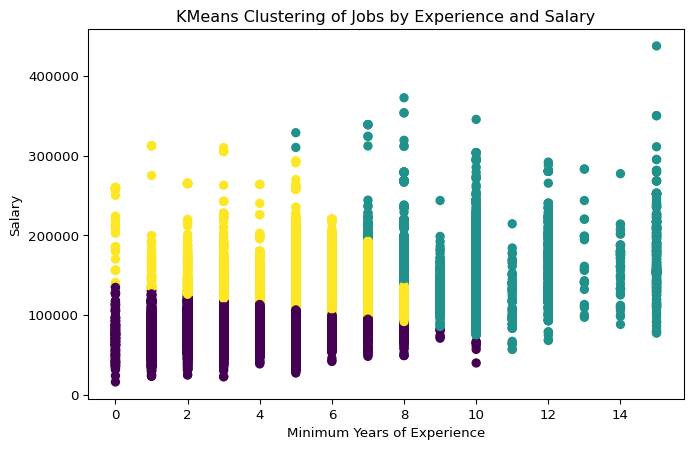

For job seekers, this result suggests that career progression is closely tied to experience accumulation. Entry-level roles may offer lower salaries, but they serve as important stepping stones toward better-paying positions.

5. Linear Regression Next, we use Linear Regression to examine whether minimum years of experience can help explain salary midpoint.

```
Regression Results
RMSE: 37343.60884288971
R²: 0.25627925864505907
Intercept: 82505.11615984552
Coefficient: 6942.344143590794
```

The regression results show a positive coefficient, indicating that jobs requiring more experience tend to have higher salary midpoints. However, the R² value is relatively low, which means that experience alone explains only part of the salary variation. Other factors such as job title, location, industry, and technical skills likely also influence salary.

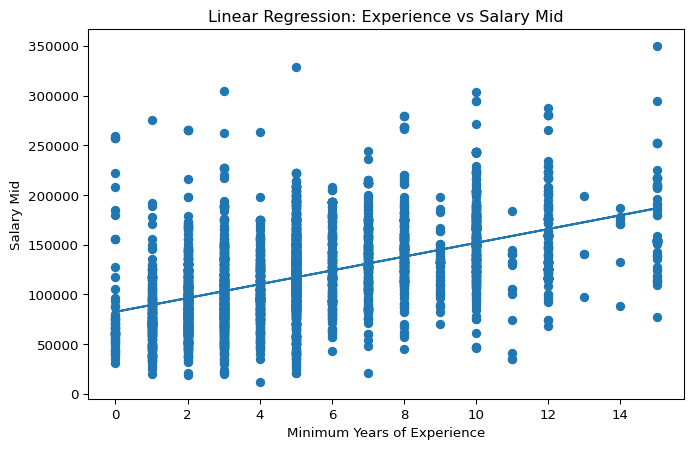

The regression plot shows an overall upward trend, meaning salary midpoint tends to rise as required experience increases. At the same time, the data points are widely scattered around the fitted line, which indicates that salary is influenced by additional variables beyond experience.

This model suggests that experience matters, but experience alone is not enough to guarantee a high salary. Job seekers should not only accumulate experience, but also improve technical skills, target stronger industries, and seek more valuable job titles.

6. Logistic Regression: Remote Job Classification Finally, we build a Logistic Regression model to classify whether a job is remote based on: Minimum Years of Experience Salary Mid

```
REMOTE_TYPE_NAME
[None]           52431
Remote           11854
Hybrid Remote     2180
Not Remote        1090
Unknown             17
Name: count, dtype: int64
Classification Results
Accuracy: 0.46850044365572313

Confusion Matrix:
[[1530 1918]
 [ 478  582]]

Classification Report:
              precision    recall  f1-score   support

           0       0.76      0.44      0.56      3448
           1       0.23      0.55      0.33      1060

    accuracy                           0.47      4508
   macro avg       0.50      0.50      0.44      4508
weighted avg       0.64      0.47      0.51      4508
```

The model achieves an accuracy of about 46.9%, which indicates relatively weak predictive performance. This suggests that salary midpoint and experience requirement alone are not strong enough to accurately predict whether a job is remote. In other words, remote work is likely influenced by other factors such as company policy, occupation type, industry, and organizational work style.

The confusion matrix shows that the model makes a considerable number of misclassifications for both remote and non-remote jobs. This means the distinction between remote and non-remote positions cannot be captured well using only these two numerical features.

The classification report also shows that the model performs unevenly across classes. This further confirms that remote status depends on more complex factors than salary and experience alone.

For job seekers, this finding is important: remote work opportunities are not simply associated with higher pay or more experience. Instead, candidates looking for remote positions should pay closer attention to: industry and job function company culture and remote policy firms known for flexible work arrangements

7. Overall Findings Across the three models, several key insights emerge: The job market can be segmented into different clusters based on salary and experience. Experience has a positive relationship with salary, but it explains only part of salary differences. Remote work status is difficult to predict using only salary and experience.
8. Recommendations for Job Seekers Based on the results above, we recommend that job seekers: Build experience gradually and strategically Develop technical and analytical skills in addition to years of experience Consider industry, occupation, and company policy when targeting remote jobs Focus not only on salary, but also on long-term career progression
9. Conclusion Overall, the machine learning analysis provides useful insights into how the 2024 job market is structured. KMeans clustering shows clear segmentation across job levels, linear regression confirms that experience is positively associated with salary, and logistic regression suggests that remote work depends on more than simple numerical characteristics. These findings help job seekers better understand how to position themselves in the job market and what factors matter most for salary growth and remote opportunities.